# Schéma : world

world, relationnel, pattes de corbeau, crowfoot

world

crowfoot

DDL

Published

September 20, 2024

Présentation du schéma `world`, pour l’entrainement à PostGres.

- **L3 MIASHS/Ingémath**
- **[Université Paris Cité](https://www.u-paris.fr)**
- Année 2025-2026
- [Course Homepage](https://bgentou.github.io/MA15E045/)
- [Moodle](https://moodle.u-paris.fr/course/view.php?id=2313)

Créé avec [DbSchema](https://dbschema.com)

## Contexte

`world` est un schéma formé par trois tables `country`, `city` et `countrylanguage`. Les instances de ce schéma sont censées fournir des données de géographie politique : un état du monde à une date donnée.

La table `country` nous renseigne sur les états reconnus (à l’ONU) et sur des territoires jugés plus ou moins autonomes [Dépendances](https://fr.wikipedia.org/wiki/Liste_des_dépendances_et_territoires_à_souveraineté_spéciale), [Territoires non autonomes](https://fr.wikipedia.org/wiki/Liste_des_territoires_non_autonomes_selon_l%27Organisation_des_Nations_unies)

La table `city` nous renseigne sur les villes les plus importantes de chaque territoire.

La table `countrylanguage` nous indique quelles langues sont parlées dans quels pays.

L’instance du schéma utilisée donne une idée du monde au début des années 2000.

## Modèle relationnel

Un modèle relationnel est formé par les tables (pour chaque colonne/attribut, nom et domaine) et des liens qui décrivent des *contraintes référentielles*.

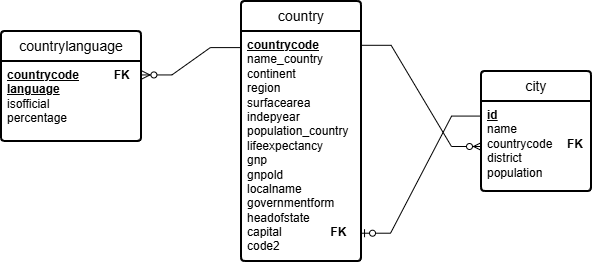

Modèle relationnel du schéma World

## Table world.country

| Idx | Name | Data Type | Description |
| --- | --- | --- | --- |
| * 🔑 ⬋ | countrycode | char(3) | Code ISO à 3 symboles |
| * | name_country | text | Nom du territoire en Anglais |
| * | continent | text |  |
| * | region | text |  |
| * | surfacearea | real | Surface en Km2 |
|  | indepyear | smallint | Année de fondation/indépendance |
| * | population_country | integer | Nombre d’habitants |
|  | lifeexpectancy | real | Espérance de vie à naissance |
|  | gnp | numeric(10,2) | PIB (en Millions de USD?) |
|  | gnpold | numeric(10,2) |  |
| * | localname | text | Nom du territoire dans les langues officielles |
| * | governmentform | text | Type de régime |
|  | headofstate | text | Chef de l’état |
| ⬈ | capital | integer | Identifiant (`id`) de la capitale dans `city` |
| * | code2 | char(2) | Code ISO à 2 symboles |

`gnp` est formé par les initiales de `Gross National Product` ([Produit National Brut](https://fr.wikipedia.org/wiki/Produit_national_brut)), un indicateur de revenu défini par les économistes.

`lifeexpectancy` (espérance de vie à la naissance) est un indicateur de santé publique construit par les démographes. Ce n’est pas l’âge moyen au décès.

Chaque ligne de `country` est identifiée par la valeur de `countrycode`. Cet attribut ne peut pas être `NULL`. Deux lignes distinctes de `country` ne peuvent coïncider sur l’attribut `countrycode`.

L’attribut `countrycode` peut être utilisé pour désigner une ligne de la table `country`. Cette possibilité est utilisée dans les tables `city` et `countrylanguage`

En jargon, l’attribut `countrycode` sert de *clé primaire* à la table `country`

Un extrait de la table concernant les pays de région `Western Europe` permet de comprendre au moins une partie de la signification et des usages des colonnes

| countrycode | code2 | name_country | localname | governmentform | headofstate | capital |
| --- | --- | --- | --- | --- | --- | --- |
| NLD | NL | Netherlands | Nederland | Constitutional Monarchy | Beatrix | 5 |
| BEL | BE | Belgium | België/Belgique | Constitutional Monarchy, Federation | Albert II | 179 |
| AUT | AT | Austria | Österreich | Federal Republic | Thomas Klestil | 1523 |
| LIE | LI | Liechtenstein | Liechtenstein | Constitutional Monarchy | Hans-Adam II | 2446 |
| LUX | LU | Luxembourg | Luxembourg/Lëtzebuerg | Constitutional Monarchy | Henri | 2452 |
| MCO | MC | Monaco | Monaco | Constitutional Monarchy | Rainier III | 2695 |
| FRA | FR | France | France | Republic | Jacques Chirac | 2974 |
| DEU | DE | Germany | Deutschland | Federal Republic | Johannes Rau | 3068 |
| CHE | CH | Switzerland | Schweiz/Suisse/Svizzera/Svizra | Federation | Adolf Ogi | 3248 |

### Foreign Keys (clée étrangères)

La colonne `capital` ne contient pas les noms de capitale (il existe des territoires sans capitale), elle contient des entiers (ou `NULL`) qui renvoient à des lignes dans la table `city`.

| Type | Name | On |
| --- | --- | --- |
|  | country_capital_fkey | ( capital ) ref world.city (id) |

### Constraints

Le domaine de la colonne (de l’atttribut) `continent` est un type énuméré (défini en extension).

| Name | Definition |
| --- | --- |
| country_continent_check | ((continent = ‘Asia’::text) OR (continent = ‘Europe’::text) OR (continent = ‘North America’::text) OR (continent = ‘Africa’::text) OR (continent = ‘Oceania’::text) OR (continent = ‘Antarctica’::text) … |

## Table world.city

| Idx | Name | Data Type |
| --- | --- | --- |
| * 🔑 ⬋ | id | integer |
| * | name | text |
| * ⬈ | countrycode | char(3) |
| * | district | text |
| * | population | integer |

Chaque ligne de `city` est identifiée par la valeur de `is`. Cet attribut ne peut pas être `NULL`. Deux lignes distinctes de `city` ne peuvent coïncider sur l’attribut `id`.

### Foreign Keys

La colonne `countrycode` ne contient pas les noms des pays, mais le code à 3 symboles du territoire où se situe la ville

| Type | Name | On |
| --- | --- | --- |
|  | city_country_fk | ( countrycode ) ref world.country (countrycode) |

L’extrait suivant correspond au villes du pays nommé `France`.

| id | name | district | population |
| --- | --- | --- | --- |
| 2974 | Paris | Île-de-France | 2125246 |
| 2975 | Marseille | Provence-Alpes-Côte | 798430 |
| 2976 | Lyon | Rhône-Alpes | 445452 |
| 2977 | Toulouse | Midi-Pyrénées | 390350 |
| 2978 | Nice | Provence-Alpes-Côte | 342738 |
| 2979 | Nantes | Pays de la Loire | 270251 |
| 2980 | Strasbourg | Alsace | 264115 |
| 2981 | Montpellier | Languedoc-Roussillon | 225392 |
| 2982 | Bordeaux | Aquitaine | 215363 |
| 2983 | Rennes | Haute-Normandie | 206229 |
| 2984 | Le Havre | Champagne-Ardenne | 190905 |
| 2985 | Reims | Nord-Pas-de-Calais | 187206 |
| 2986 | Lille | Rhône-Alpes | 184657 |
| 2987 | St-Étienne | Bretagne | 180210 |
| 2988 | Toulon | Provence-Alpes-Côte | 160639 |
| 2989 | Grenoble | Rhône-Alpes | 153317 |
| 2990 | Angers | Pays de la Loire | 151279 |
| 2991 | Dijon | Bourgogne | 149867 |
| 2992 | Brest | Bretagne | 149634 |
| 2993 | Le Mans | Pays de la Loire | 146105 |
| 2994 | Clermont-Ferrand | Auvergne | 137140 |
| 2995 | Amiens | Picardie | 135501 |
| 2996 | Aix-en-Provence | Provence-Alpes-Côte | 134222 |
| 2997 | Limoges | Limousin | 133968 |
| 2998 | Nîmes | Languedoc-Roussillon | 133424 |
| 2999 | Tours | Centre | 132820 |
| 3000 | Villeurbanne | Rhône-Alpes | 124215 |
| 3001 | Metz | Lorraine | 123776 |
| 3002 | Besançon | Franche-Comté | 117733 |
| 3003 | Caen | Basse-Normandie | 113987 |
| 3004 | Orléans | Centre | 113126 |
| 3005 | Mulhouse | Alsace | 110359 |
| 3006 | Rouen | Haute-Normandie | 106592 |
| 3007 | Boulogne-Billancourt | Île-de-France | 106367 |
| 3008 | Perpignan | Languedoc-Roussillon | 105115 |
| 3009 | Nancy | Lorraine | 103605 |
| 3010 | Roubaix | Nord-Pas-de-Calais | 96984 |
| 3011 | Argenteuil | Île-de-France | 93961 |
| 3012 | Tourcoing | Nord-Pas-de-Calais | 93540 |
| 3013 | Montreuil | Île-de-France | 90674 |

La description des tables `country` et `city` n’impose pas que la capitale d’un pays soit une ville située dans ce pays.

Est-ce que cette contrainte devrait être mise en place ?

## Table world.countrylanguage

La table `countrylanguage` nous renseigne sur les langues parlées dans les différents pays.

| Idx | Name | Data Type |
| --- | --- | --- |
| * 🔑 ⬈ | countrycode | char(3) |
| * 🔑 | language | text |
| * | isofficial | boolean |
| * | percentage | real |

Un extrait correspondant au pays `FRA` (France) aide à comprendre

| countrycode | language | isofficial | percentage |
| --- | --- | --- | --- |
| FRA | French | t | 93.6 |
| FRA | Arabic | f | 2.5 |
| FRA | Portuguese | f | 1.2 |
| FRA | Italian | f | 0.4 |
| FRA | Spanish | f | 0.4 |
| FRA | Turkish | f | 0.4 |

Les lignes nous renseignent sur 6 langues. Une documentation complète serait nécessaire pour vérifier si le `percentage` correspond à la proportion d’individus qui déclarent telle ou telle langue comme langue maternelle. On ne sait pas si un individu peut déclarer posséder plusieurs langues.

La documentation d’une base de données ne se réduit pas toujours à un diagramme.

D’après l’instance du schéma `world`, la seule langue réputée officielle en France est le français.

Qu’est ce qu’une langue officielle ?

Dans la table `countrylanguage`, l’attribut `countrycode` renvoie à une ligne de `country` grâce à l’attribut de même nom dans la table `country.`

### Foreign Keys

| Type | Name | On |
| --- | --- | --- |
|  | countrylanguage_countrycode_fkey | ( countrycode ) ref world.country (countrycode) |

Dans le schéma `world`, chaque ligne de `countrylanguage` est identifiée par les valeurs des colonnes `countrycode` et `language`. On parle de *clé primaire* composée.